# STAA 577: Laboratory Seven Beyond Linearity (`tidyverse`) version

## 5.2 Compare, summarize, and predict

Fit two additional models and compare to the original `gam_m3` using ANOVA. The models are:

- **gam_m1**: excludes `year` as covariate
- **gam_m2**: includes `year` as a *linear* covariate
- **gam_m3**: includes `year` as a *non-linear* spline function (`df = 4`)

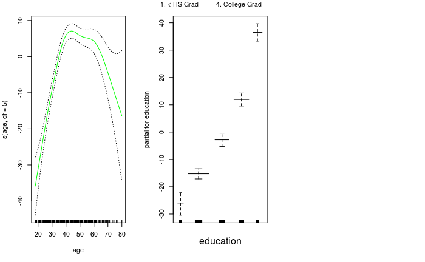

```r
gam_m1 <- gam::gam(wage ~ s(age, df = 5) + education, data = Wage)
par(mfrow = c(1, 3))
plot(gam_m1, se = TRUE, col = "green")

gam_m2 <- gam::gam(wage ~ year + s(age, df = 5) + education, data = Wage)
par(mfrow = c(1, 3))
```

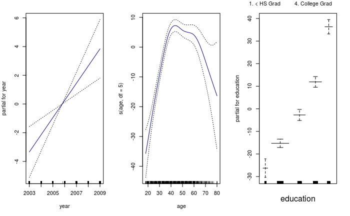

```r
plot(gam_m2, se = TRUE, col = "navy")

gam_m3 <- gam::gam(wage ~ s(year, df = 4) + s(age, df = 5) + education,
                   data = Wage)
par(mfrow = c(1, 3))
```

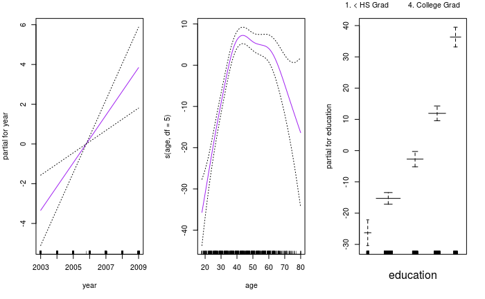

```r
plot(gam_m2, se = TRUE, col = "purple")
```

```r
anova(gam_m1, gam_m2, gam_m3, test = "F")
```

```
Analysis of Deviance Table

Model 1: wage ~ s(age, df = 5) + education
Model 2: wage ~ year + s(age, df = 5) + education
Model 3: wage ~ s(year, df = 4) + s(age, df = 5) + education
  Resid. Df Resid. Dev Df Deviance       F    Pr(>F)
1      2990    3711731
2      2989    3693842  1  17889.2 14.4771 0.0001447 ***
3      2986    3689770  3   4071.1  1.0982 0.3485661
---
Signif. codes:  0 ‘***’ 0.001 ‘**’ 0.01 ‘*’ 0.05 ‘.’ 0.1 ‘ ’ 1
```

```r
# Based on the ANOVA, `gam_m2` is preferred
summary(gam_m2)
```

```
Call: gam::gam(formula = wage ~ year + s(age, df = 5) + education,
    data = Wage)
Deviance Residuals:
     Min       1Q   Median       3Q      Max
-119.959  -19.647   -3.199   13.969  213.562

(Dispersion Parameter for gaussian family taken to be 1235.812)

    Null Deviance: 5222086 on 2999 degrees of freedom
Residual Deviance: 3693842 on 2989 degrees of freedom
AIC: 29885.06

Number of Local Scoring Iterations: 2

Anova for Parametric Effects
                 Df  Sum Sq Mean Sq F value    Pr(>F)
year              1   27154   27154  21.973  2.89e-06 ***
s(age, df = 5)    1  194535  194535 157.415 < 2.2e-16 ***
education         4 1069081  267270 216.271 < 2.2e-16 ***
Residuals      2989 3693842    1236
---
Signif. codes:  0 ‘***’ 0.001 ‘**’ 0.01 ‘*’ 0.05 ‘.’ 0.1 ‘ ’ 1

Anova for Nonparametric Effects
               Npar Df Npar F     Pr(F)
(Intercept)
year
s(age, df = 5)       4  32.46 < 2.2e-16 ***
education
---
Signif. codes:  0 ‘***’ 0.001 ‘**’ 0.01 ‘*’ 0.05 ‘.’ 0.1 ‘ ’ 1
```

```r
# Don't forget about `broom::tidy()`
# Easily and consistently summarize model output
broom::tidy(gam_m2)
```

| term | df | sumsq | meansq | statistic | p.value |
| --- | --- | --- | --- | --- | --- |
| year | 1 | 27153.97 | 27153.971 | 21.97258 | 2.889526e-06 |
| s(age, df = 5) | 1 | 194535.50 | 194535.497 | 157.41516 | 3.156745e-35 |
| education | 4 | 1069081.29 | 267270.322 | 216.27108 | 3.476608e-163 |
| Residuals | 2989 | 3693841.51 | 1235.812 | NA | NA |

```r
# Compare to `gam_m3`
broom::tidy(gam_m3)
```

| term | df | sumsq | meansq | statistic | p.value |
| --- | --- | --- | --- | --- | --- |
| s(year, df = 4) | 1 | 27162.12 | 27162.12 | 21.98134 | 2.876593e-06 |
| s(age, df = 5) | 1 | 195338.46 | 195338.46 | 158.08049 | 2.301508e-35 |
| education | 4 | 1069726.09 | 267431.52 | 216.42285 | 2.873920e-163 |
| Residuals | 2986 | 3689770.38 | 1235.69 | NA | NA |

Finally, we use the built-in S3 `Gam` method to the `predict()` generic to make predictions on the training set & calc MSE. The `predict()` generic lives in `stats` package. It is not necessary to select the model covariates first, this will happen internally within `predict`. However, it can be a good practice to do so, to ensure you’re not accidentally cheating. Below we use `dplyr::select` to keep *only* the predictors in the `new data`.

```r
pred_wage <- predict(gam_m2, newdata = dplyr::select(Wage, year, age, education))
mse       <- mean((wage - pred_wage)^2)   # calculate MSE
mse
```

```
[1] 1231.281
```

Created on 2018-12-12 by [Rmarkdown](https://github.com/rstudio/rmarkdown) (v1.10) and R version 3.5.1 (2018-07-02).